# Data Driven Analysis of Player Performance

Project Report for STAT 303-1 Fall 2025

Author

Javier Hernandez

Published

December 9, 2025

Abstract

*This project examines the key factors that influence a players rating, performance across age groups, variation in player quality, and recommendations on which players to but. The analysis identifies the technical and mental characteristics most strongly correlated with player rating and value, including interception, composure, ball control, and short and long passing. Overall, these findings give insights in how teams can be more effective in recruiting, scouting, and developing players by focusing on attributes depending on a players age range. The only issue is the dataset is outdated meaning some new players are not in the dataset as well as current players rating may not be up to date*.

## 1) Inspiration

According to Forbes, Manchester United was the team to beat in England for the better part of three decades. However, all of that changed with the departure of the legendary Sir Alex Ferguson. His exit marked the beginning of an unexpected and dramatic decline. Since Ferguson walked away with the club’s last Premier League title, United has only challenged for the league once—and even then, they finished a distant second. Although some silverware has been won, the past few seasons have been underwhelming compared to the Ferguson era. What is most surprising is that the club has continued to increase its revenue while performances on the pitch have been disappointing. Despite higher revenues and a rising valuation, Manchester United has repeatedly failed to qualify for the most lucrative European competition: the Champions League.

To put this into perspective, Manchester United was valued at $3 billion when it last won the Champions League, with revenues of $385 million. Even after 12 years of poor performances, the club is now valued at $7 billion and generates around $800 million in revenue.

Since Ferguson left, there have been eight different managers in the span of twelve years. This level of turnover creates instability and prevents any manager from implementing a long-term system or defining a consistent style of play. Beyond managerial instability, there is also a lack of squad depth. United does not have enough high-quality players on the bench to compete throughout the Premier League season or to consistently qualify for the Champions League. While the starting eleven remains solid, it is no longer exceptional.

Another major issue is the inconsistency of the players brought into the club, which stems from poor recruitment. Manchester United has spent large transfer fees on players like Antony, Jadon Sancho, Rasmus Højlund, and Mason Mount, relying heavily on them without having adequate backup options. When these players struggle or suffer injuries, there is no equally promising talent available to step in. United needs to focus on recruiting a balanced mix of young players with potential and experienced players who can offer leadership, guidance, and stability.

This analysis is not only useful for Manchester United but also for any club with significant financial resources that aims to strengthen its squad. This analysis will highlight players and key characteristics for recruiting, looking at different variables such as how different variables affect a player’s rating.

## 2) Problem Statements

1. Who are the top 3 best defensive midfielders? What characteristics make them better than the rest of the midfielders?
2. Which variables are the most strongly correlated with the overall rating and market value?
3. How does player performance vary by age/position? That is is there a strong influence on the age of the player with there overall rating?
4. Which nationalities produce the highest-rated players, and how consistent is player quality across countries?

## 3) Data

Data Identification:

https://www.kaggle.com/datasets/maso0dahmed/football-players-data

Description: This comprehensive dataset offers detailed information on approximately 17,000 FIFA football players, meticulously scraped from SoFIFA.com.It encompasses a wide array of player-specific data points, including but not limited to player names, nationalities, clubs, player ratings, potential, positions, ages, and various skill attributes. This dataset is ideal for football enthusiasts, data analysts, and researchers seeking to conduct in-depth analysis, statistical studies, or machine learning projects related to football players’ performance, characteristics, and career progressions.

Data Description: There are 17,594 observations and 51 variables. Each row represents a soccer player from a professional soccer league. Each variable represents key information about a player such as there position, their overall ranking, possession, potential, etc.

Out of the 51 variables, there are 14 categorical variables and 37 continuous variables.

Categorical Variables:  
• name,  
• full_name,  
• birth_date,  
• age, positions,  
• nationality,  
• preferred foot,  
• body_type,  
• national_team,  
• national_team_position,  
• international_reputation(1-5),  
• weak_foot(1-5),  
• skill_moves(1-5),  
• national_jersey_number

Continuous Variables:  
• heigh_cm,  
• weight_kgs,  
• overall_rating,  
• potential,  
• value_euro,  
• wage_euro,  
• release_clause_euro,  
• national_rating,  
• crossing,  
• finishing,  
• heading_accuracy,  
• short_passing,  
• volleys,  
• dribbling,  
• curve,  
• freekick_accuracy,  
• long_passing,  
• ball_control,  
• acceleration,  
• sprint_speed,  
• agility,  
• reactions,  
• balance,  
• shot_power,  
• jumping,  
• stamina,  
• strength,  
• long_shots,  
• aggression,  
• interceptions,  
• positioning,  
• vision,  
• penalties,  
• composure,  
• marking,  
• standing_tackle,  
• sliding_tackle

Throughout the analysis I used most of the variables. Only a couple were focused on and highlighted. In question one and two there were variables that were not used, such as; nationality, national_jersey_number, national_team_position, release_clause_euro, wage_euro. As they won’t have any correlation with how well the player performs, and since not all players play with their national team it is just missing data that is not needed for these questions.

## 4) Stakeholders

#### MANCHESTER UNITED RECRUITING TEAM

This analysis is meant for Manchester United and their recruiting team on how to systematically improve their squad, but also their players’ quality and depth. They could use this analysis to target specific players based on their needs and struggles. For example, as of now, Manchester United needs a strong pivot to help in the transition from defense to offense. I strongly believe that with these insights, Manchester United will be able to gain a better understanding of players to target going into the next transfer window.

#### CLUBS WITH HIGH BUDGET BUT POOR RESULTS

Although this analysis is meant for Manchester United, it will also be helpful for big teams that have been performing poorly. Such as Tottenham, Juventus, AC Milan, and Roma. This analysis will help them identify key positions and players that may fit their system and be able to focus on going into the transfer market. I believe that with these insights, these big clubs will be able to gain a better squad depth as well as players that fit their system and become more successful in the upcoming years.

#### FOOTBALL ANALYST DATA TEAMS & PERFORMANCE DEPARTMENTS

Football analysts and performance departments would also benefit from looking into this analysis, as a lot of the basis of what Football Analysts do has to do with this type of work. Analyzing players and seeing which players are performing well based on metrics and which players are not performing as they should. Possibly seeing which players underperformed and what caused them to do so, as well as working with coaches to develop strategies, identifying player strengths and weaknesses, and assisting in scouting.

## 5) Data Cleaning

### a) Cleaning - Question 1

I first searched for any missing values in the variables that I used for this analysis. There were some missing values in variables such as value_euro, wage_euro, release_clause_euro, national_team, national_rating, national_team_position, and national_jersey_number. However, I decided not to impute any of these variables, as many of the reasons why these variables are missing are that not all of the players play for their national team. Imputing this may just affect the data and give false values for the data that we have.

In the numerical variables, there are no outliers, as many of the numbers fall within a certain range. Most variables are from 1-100 or 1-5. Meaning that there can’t be any values that are outside of that range. This is helpful, as these evaluation metrics show us that there aren’t any incorrect values or zero weight in the variables that were used for analysis.

We used a different number of categories and variables. Most of the categorical variables have five different categories, as it is asking for some of the players’ characteristics to be evaluated out of five. For example, one being poor and five being mastered.

Finally for this part of the analysis, the data showed that there are some CDMs that can play Center Midfielder (CM). However, not all CM play CDM. So we filtered the data based on the players that are mainly CDMs but can also play CM. This information will make it more visible in choosing the best CDMs from these players and what exactly makes them better than the rest.

### b) Cleaning - Question 2

First, I searched for any missing values, specifically in variables that were needed for the analysis of this question. Since this was split up into three different sections, I had to look at the variables and their missing values for the three different types of situations. For this question, we discarded variables that don’t have an impact on the overall rating of a player. Some of the discarded variables were nationality, national_jersey_number, national_team_position, release_clause_euro, and wage_euro.

The numerical variables for this analysis are either metrics of a player or a rating from a specific range, so there weren’t any underlying outliers in the data. Because the values of these variables are from a certain range, it means that we don’t have any incorrect values or zero weight in the variables.

I then filtered different variables depending on the positions of the players. As we analyzed the different impacts and characteristics that are evaluated, we looked at whether a player was an attacker, defender, or all of the players. Since the players are evaluated in a different way depending on their positions. Seeing the correlation of what makes a player ranked higher than others, depending on their position, is more valuable, but we also wanted to highlight what impacts a player’s overall rating and value without the restriction of positions.

### c) Cleaning - Question 3

There were no missing values for the age variable, so there was no imputing done. For this analysis we had to see what the range of age was to determine how we would break up the age groups. As the range was from 17-46 I decided to create four groups that would be best to represent the different types of age ranges.

There were no heavy outliers in the dataset as all of the players were within this age range. However the only ones players that were outliers in there respective groups were of age 17 and 46. As they were the youngest and the oldest players in the dataset. I decided not to do anything about the outliers, since they still tell a great story about these players. For example, in this dataset Kylian Mbappe was 17 years old and although this may have some effect on the dataset, we know that he has great potential. As he is now thriving and may be considered one of the best players in the world.

For this questions the variables that were mostly used were age, overall_rating, acceleration, sprint_speed, dribbling, ball_control, finishing, short_passing, stamina, strength. These are the variables that will be used to evaluate the players based off of age as well as some comparison between the age of a player and there overall rating.

### d) Cleaning - Question 4

First, there was not values that were missing for nationality. All players in the dataset has an origin of where they came from. Initially this was gonna be done by only examining the players that played in a national team. However after doing more examining I noticed that there were only 857 players that played in their own national teams.

There were many outliers in the dataset due to there only being a few players for a country. There were 86 countries that had less than 20 players. So I decided to drop those countries from the data, by dropping these countries I avoided small-sample countries from the dataset. Initially there were multiple small countries that were the highest overall rating, this was due to the amount of players, as they would take the average on only one or two players. Having these types of points would have skewed the dataset, leaning on the smaller countries to have a greater overall rating of the player just based off having a couple of players. Not really making it fair for the rest of the countries such as spain which contains 1070 players.

Luckily because we were looking at a players nationality we did not encounter any type of incorrect values or misspelling within the values. The variables that were used for this question was primarily the nationality of each player, there overall_rating, potential, and the value_euro.

## 6) Data Analysis

### a) Analysis 1

I was looking for the player characteristics that were the most correlated with the overall rating of a Center Defensive Midfielder. To do so I filtered the dataset into the variables that were the most important when looking at a CDM, these were a players; name, age, positions, overall_rating, potential, value_euro, short_passing, dribbling, long_passing, ball_control, acceleration, stamina, strength, aggression, interceptions, positioning, vision, composure, marking, standing_tackle, and sliding_tackle. With the data that was given to us these variables captivate a midfielder and how they should be rated, from this I created a data frame.

From the data frame crated I correlated the variables to the overall_rating of a CDM. I then sorted the values by descending values, and found the five most correlated variables those being interceptions, composure, ball control, short passing, and long passing.

I next moved onto visualizing the data. This message was conveyed through a heatmap of all correlated variables from the CDM analysis:

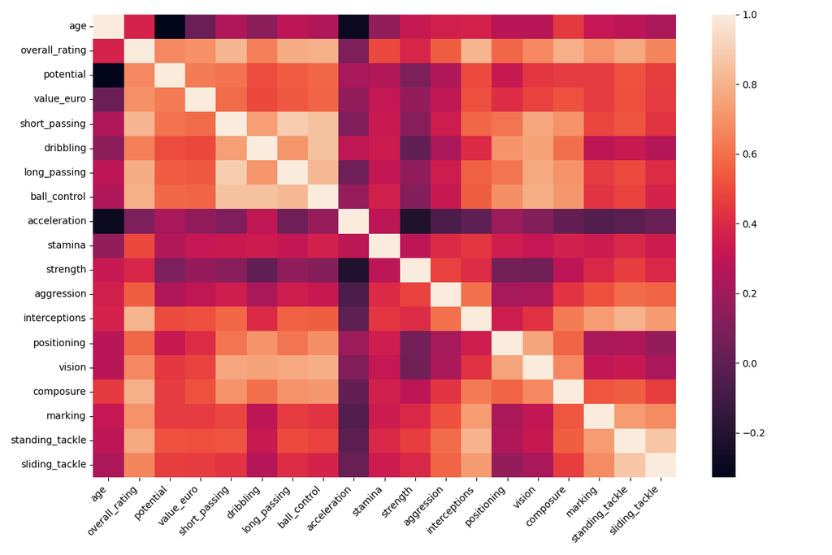

Correlation Heatmap

I then moved onto finding the best CDM, this was done by ranking the players based off of these correlated variables. The players that were the highest ranked in these top 5 variables were Sergio Busquets, NGolo Kante, Ivan Rakitic, Casemiro, and Thiago. Once I filitered out these players I acquired there values in these variables and was able to compare them against the average of all other CDMs.

To do so I used radar charts as they capture a players comparison against the rest of the CDM players. Showing a specific players strengths across the rest of the players as well as highlighting there weaknesses. The blue pentagon is used to demonstrate the player that we are trying to highlight, while the red pentagon is the average across all CDMs and how they rank on these characteristics.

First, we start with Sergio Busquets who at the time played for FC Barcelona. He was rated the best CDM and he excels in all positions, scoring higher in every characteristic than other CDMs. On average he has a higher rating than other players on all characteristics. Having 22 higher rating points on short passing, 23 on interceptions, 30 on composure, 23 on ball control, and 17 on long passing. Making him an exceptional player on all types of CDM characteristics.

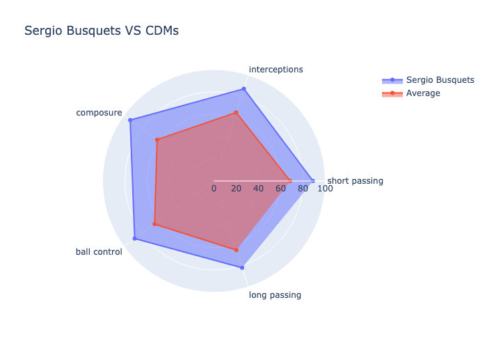

Radar Chart

We then looked at Ngolo Kante who played for Chelsea at the time. He was rated the second best CDM as he also excels in all positions scoring higher in every characteristic than other CDMs. As on average has a higher rating than other players on all characteristics. Having 18 higher rating points on short passing, 28 on interceptions, 22 on composure, 15 on ball control, and 18 on long passing. Making Ngolo an incredible player not only being able to play on the ball but also having an incredible work ethic and defensive work rate.

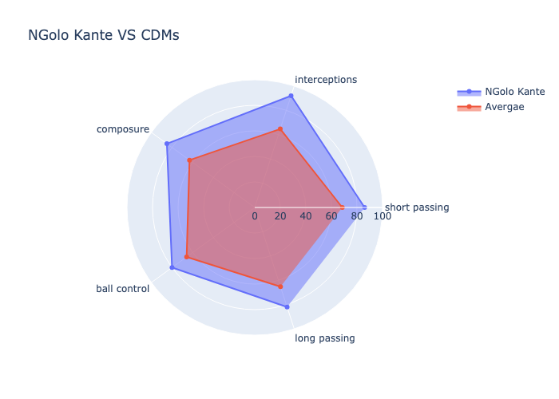

Radar Chart

Third rated was Ivan Rakitić who also played for FC Barcelona at the time. He plays as a CDM/CMand is a great ball possession player, reads the game well, and can control the pace of the game. Ivan Rakitić is more of a balanced midfielder although likes to attack and does well, but is also a very defensive minded player. Ivan Rakitić on average has a higher rating than all other players in the top 5 most correlated characteristics with the overall rating of a CDM. Having a higher rating on average, for short passing by 19, interceptions by 17, composure by 23, ball control by 20, and long passing by 25. Making Ivan Rakitić an exceptional option as a CDM one that not only is aggressive but also very composed on the ball.

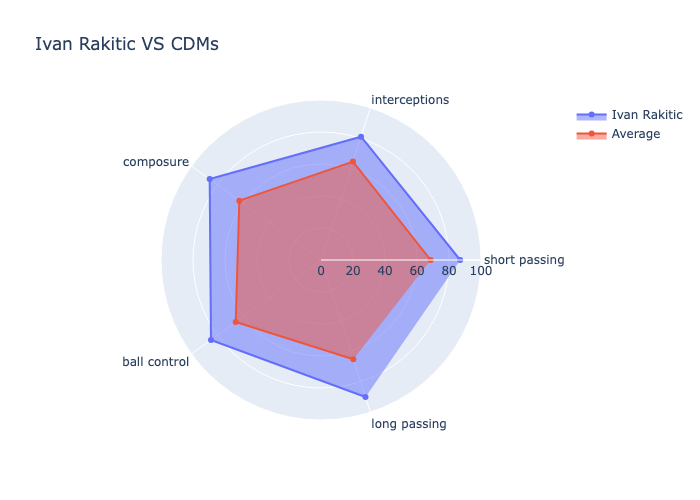

Radar Chart

Fourth rated was Casemiro, who at the time played for Real Madrid and ultimately ended up joining Manchester United. He is known for being a very aggressive midfielder and very defensive minded. Does not do so well under pressure, but it would be difficult to get passed him. Now in terms of characteristics, he excels in every aspect compared to the average of all other players. Having a higher rating on average, for short passing by 15, interceptions by 22, composure by 21, ball control by 13, and long passing by 18. Making him a great option, the only worry about Casemiro is his age, he is getting at an age where he may only have a couple more years of high competitive football.

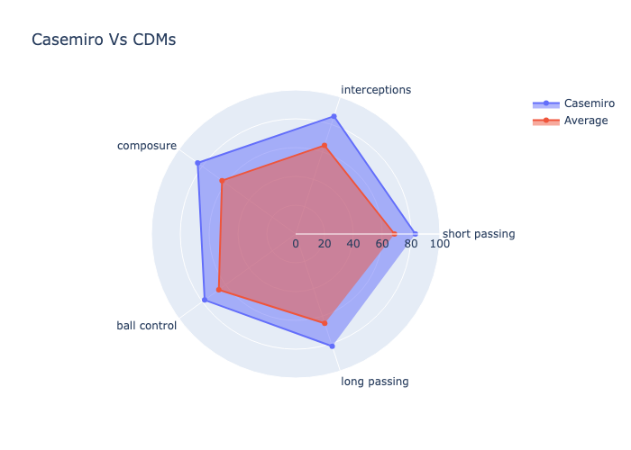

Radar Chart

Finally we have Thiago, who at this time played for Bayern Munich and was exceptional for them. As a Brazilian he had many skilful moves to move past an opposition with ease in the midfield, he is shifty, rarely lost the ball, and was in his prime. Although a more attacking midfield, he could play the CDM role exceptionally well. Having a higher rating on average, for short passing by 22, interceptions by 14, composure by 22, ball control by 25, and long passing by 22. Making him a great option, not only to play as a CDM but also as rotation when needing a Center Attacking Midfielder (CAM) with his creativity and aggression.

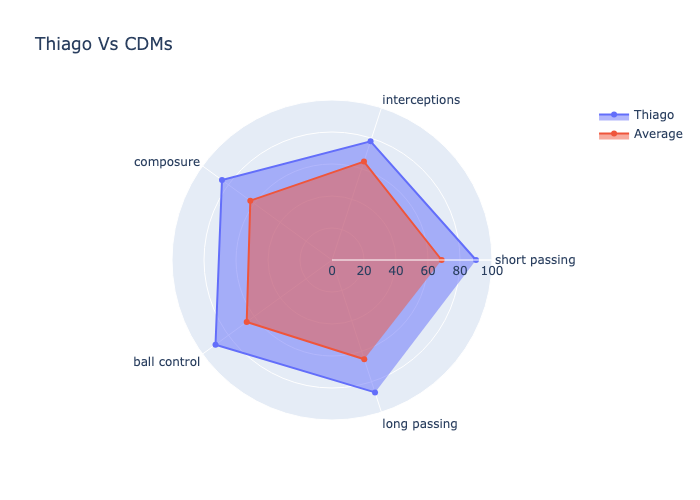

Radar Chart

### b) Analysis 2

I divided the question into three different sections looking at what had a impact on players overall rating, attacker overall rating, and defenders overall rating. As well as also looking at what had an effect on their overall market value. As a lot of the metrics may be different due to players needing to perform better in different aspects of the game depending on position.

I created a heatmap using the ten most influential variables across both categories (rating and market value).

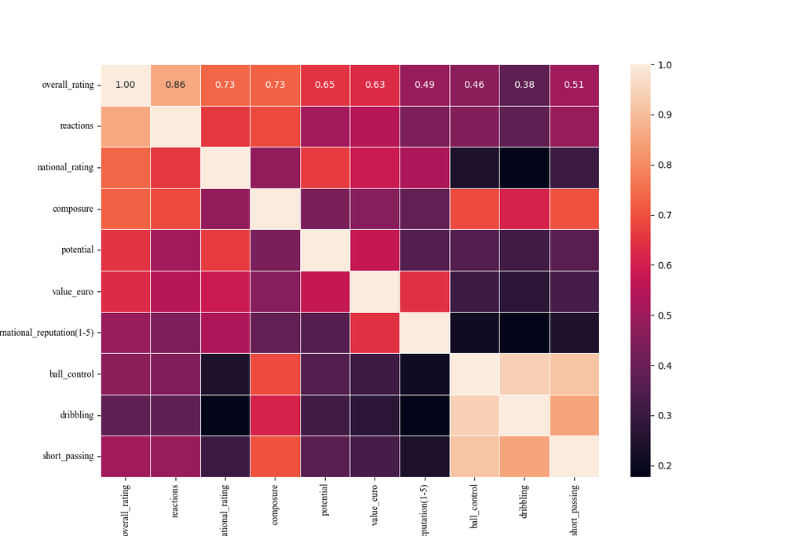

Correlation Heatmap

I then computed the correlation between every numerical variable and the overall_rating. After sorting the correlations, I extracted the top six most influential variables which were:

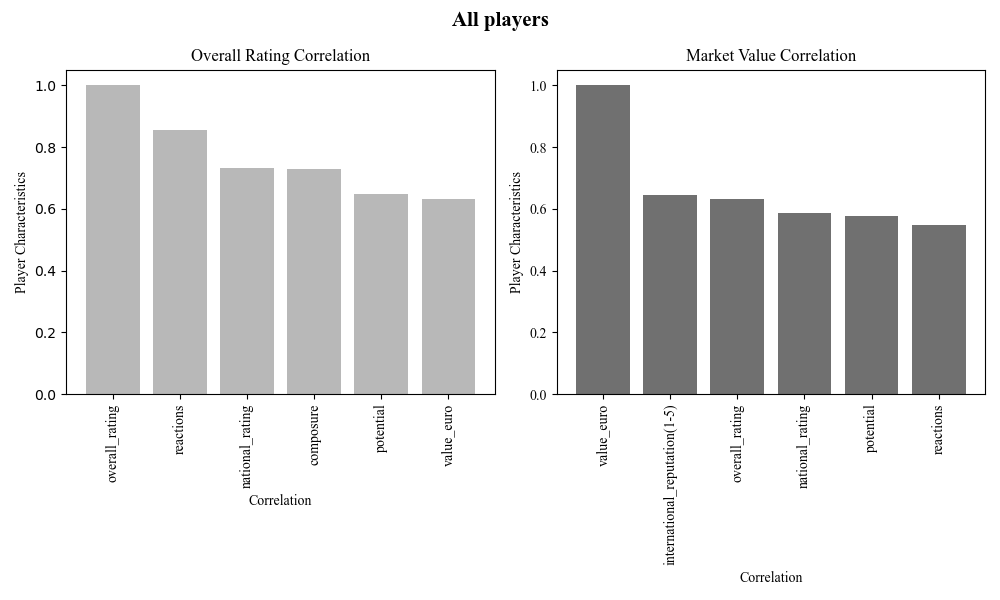

To better show the relationship between specific traits and the overall rating, I generated two regression plots.

First the visual to the left demonstrating a strong linear relationship with a players rating and their reactions. Players with higher reactions almost always have a higher overall rating. This helps confirm that reactions is one of the most strongest predictors of rating.

The visual on the right shows the same trends as reactions. Composure increases consistently with overall rating, reinforcing the importance of calmness and decision-making ability.

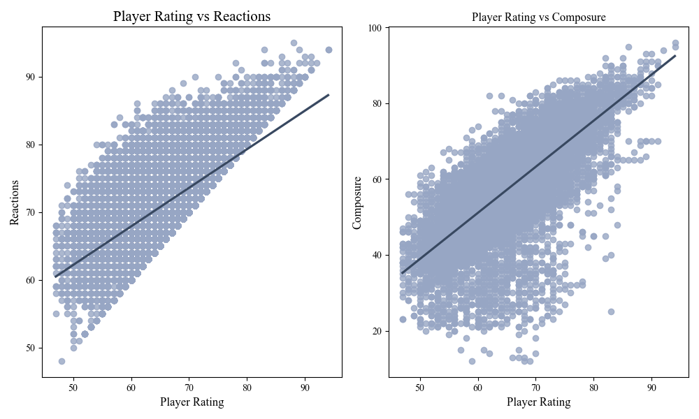

Scatter Plot

To examine how the value of a palyer relates to player performance, I created categories (Talent, Squad Rotation, Reliable Player, Key Player, Star Asset, and Elite) using bins of value_euro.

The scatter plot to the lest showing the relationship between a player rating and their value category shows that as players move into higher value brackets, their overall rating rise. The pattern confirms that market value reliably increases with a players ability.

The scatter plot to the right follows the same upward trend, showing that the more valuable players tend to perform well internationally. Also giving us information that high rated players do perform well under pressure with there national team compared to a group like “Talent”.

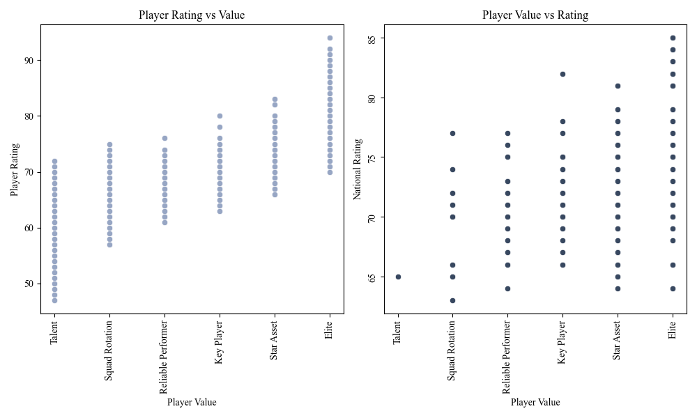

Scatter Plot

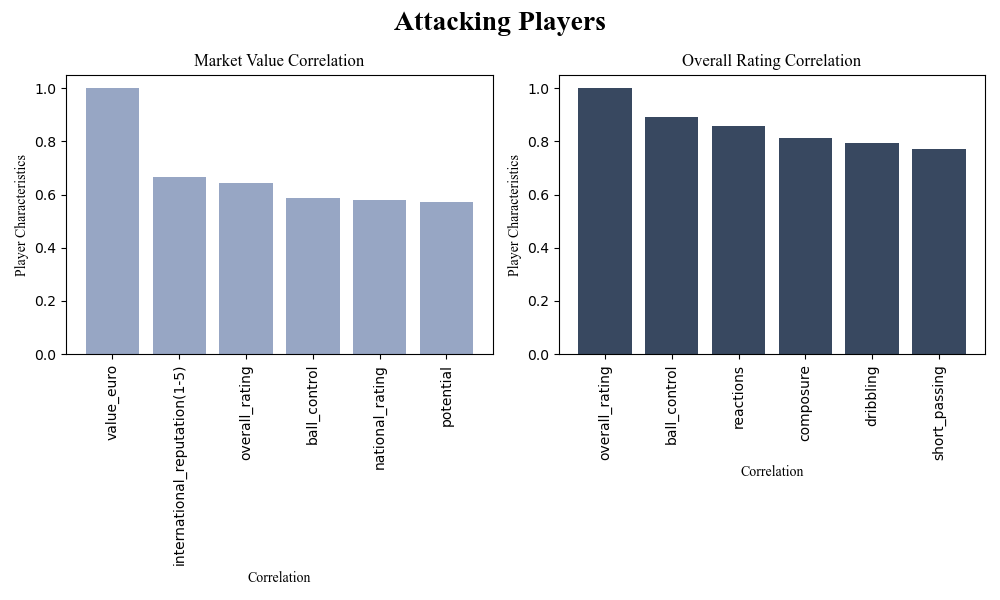

Bar Plot

Finally I repeated the analysis for defensive players. The left bar plot highlights that the defensive players value is driven by a majority of what attacker and overall players are valued by. Such as the overall_rating, national rating, potential, reactions, and international reputation. These traits reflect how well they are composed on the ball and how fast they can make decisions when it comes to defending.

The right bar plot predictors align with how well they are composed on the ball and how well they can defend. We see that a major part of how players are rated is being comfortable on the back, and how well they can react to quick situations. As a defender its really important to be reliable and comfortable on the ball as this analysis shows.

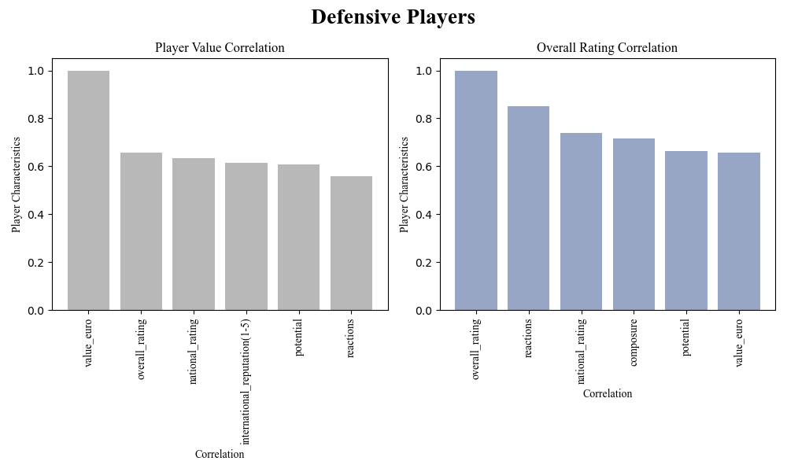

Across the analysis, the strongest consistent variables of high overall rating and market values were:

- Technical Ability: ball control, dribbling, and short passing
- Mental Attributes: reactions and composure
- Player Reputation: national rating, international reputation
- Potential

### c) Analysis 3

To understand how players performance change depending on their age, I analyzed the relationship between age and overall rating. I created age groups (Young Adults, Adults, Senior Adults, and Veterans), and compared the average technical and physical attributes across different age categories. This allowed me to observe both general trends and specific performance differences across age ranges.

I first plotted a line graph showing how a player’s overall rating changes with age. This reveals how players develop, peak, and eventually decline as they get older.

The line plot shows the performance curve that:

- Ratings increase steadily from ages 17-24 as players develop both physically and mentally.
- Between the ages of 25-33, players hit their optimal/peak performance window, showing the highest overall ratings.
- Once a player reaches the age of 35, there is a gradual decline, and becomes even more noticeable after the age of 40.

This closely aligns with tht typical player development, where athletes hit there peak in their mid-to-late 20s and then gradually decrease as physical attributes are not what they used to be.

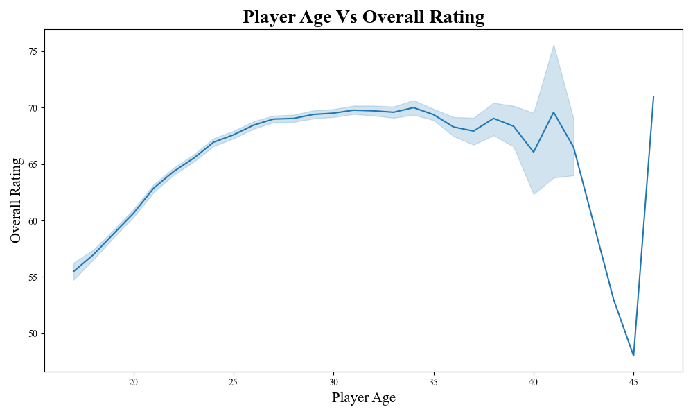

Line Plot

To explore how players within the same age group differ, I used the bins for age ranges I had created and plotted the distribution of rating within each group.  
The box plot compares the spread of overall rating across the four age groups.

This plot makes it clear that a players prime occurs in the senior adult age bracket. While young adult and adults are steadily increasing slowly with there performance and reaching optimal performance.

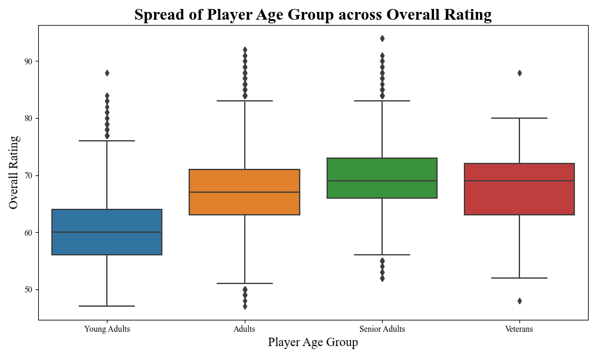

Box Plot

To understand why players peel at certain ages, I analyzed the average values for key technical and physical attributes across age groups. Including

- Acceleration
- Sprint Speed
- Dribbling
- Ball Control
- Finishing
- Short Passing
- Stamina
- Strength

I then visualized these using a radar chart for comparing the four age categories. This radar chart reveals how physical and technical abilities evolve with age.

Young Adults (17-20) have a strong acceleration and sprint speed. They compare lower in finishing and decision making attrbiuted to the ongoing development and lack of experience.

Adults (21-28) have the highest score in most technical and physical attributes. This is because this is considered the peak performance of a player, dominating in ball control, dribbling, short passing, and stamina.

Senior Adults (29-37) still maintain strong technical ability. However, we start seeing a small decline in acceleration and sprint speed. Strength improves slightly due to the experience and conditioning of the player.

This visual clearly shows the transition from physically explosive players (Young Adults), technical dominant player (Adults), and more tactically experienced players (Veterans).

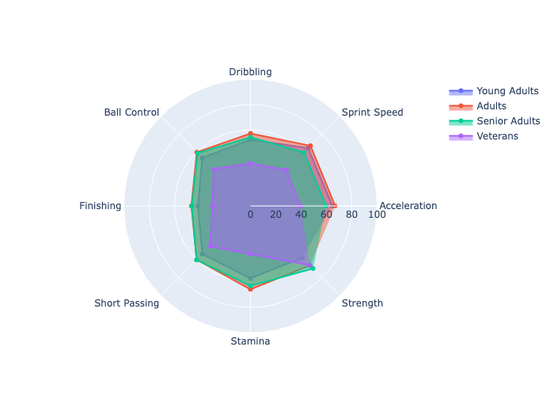

Radar Chart

### d) Analysis 4

The dataset contains players from over 160 different nations, showing a very diverse pool in the dataset. However, many of these nations only have a couple of players. So I decided to filter by the amount of players to help with consistency.

After grouping by nationality and calculating te mean overall rating for each the countries players, I selected the top 10 nations with the highest average player ratings that had at least 20 players.

This bar char displays the countries with the highest player ratings:

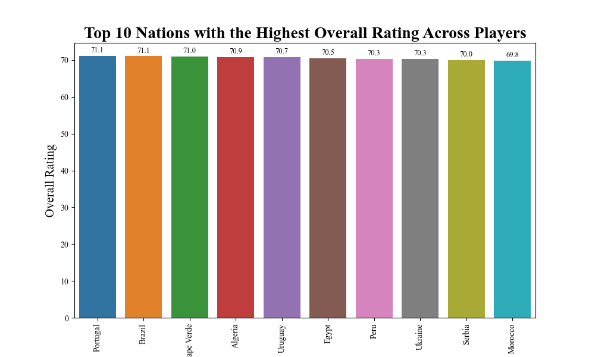

Bar Plot

Next I examined the distribution of player ratings within the top 10 countries to understand how consistent their player development is. Some nations may have a couple of superstars that bring up the average, while other countries may be more balanced.

The boxplot shows the spread such as the minimum, median, maximum, and quartiles of players rating for each country.

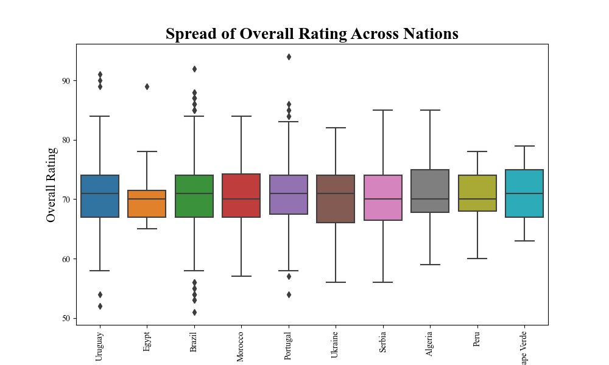

Box Plot

Each point in this scatter plot represents a nationality, showing its average player ration on the x-axis and the rating variability (standard deviation) on the y-axis.

On the bottom-right quadrant(high rating and low variability) there are countries like Peru, Egypt, and Cape Verde. These countries produce strong and consistent players, this is the ideal combination when looking at an overall rating.

The top-right quadrant (high rating and high variability) we see countries like Brazil, Uruguay, and Portugal. Producing elite starts but also more variance in talent. They are known for producing world class players. For brazil; Neymar, Ronaldinho, Ronaldo. For Portugal; Ronaldo, Figo, and Bruno Fernandes.

the Top-left quadrant(low rating and high variability) countries like Serbia, Ukraine, and Morocco does not develop great players and are generally weaker in overall rating.

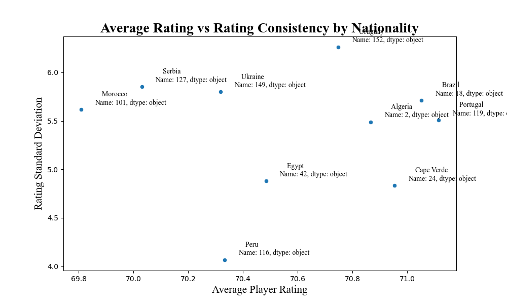

Scatter Plot

### a) Recommendation 1

Sergio Busquets is the obvious option as he excels compared to all other CDMs. However one thing to keep in mind is his commitment to his current team Barcelona. Sergio Busquets is valued at $51M meaning that is how much he will be going on for the market, however as he has been with Barcelona for his whole career getting him to leave will need a big transfer fee and high wages to even consider him. So I would not recommend to prioritize this transfer.

I would say that the safest option especially for Manchester United is to prioritize Thiago in the transfer window. Thiago is not only still in his prime only being 27 but he is able to play CDM, CM, and CAM. He has more of an attacking mindset but still performs better than most of the CDMs. Thiago would be crucial in progressing the ball from the first third of the field to the second and possibly third part. Now his creativity is second to none and as of now Manchester United need someone who is comfortable with the ball and be able to turn when under pressure, while still delivering great through balls.

### b) Recommendation 2

When Recruiting a player some of the key in game characteristics that one should be focusing on is reactions, composure, potential, ball control, dribbling, short passing, and international reputation (depending if they do play for their nation).  
The three most in game characteristics to focus on is composure, as this can tell a lot about a player. How well are they off the ball on the ball, do they lose the ball quickly, what exactly do they do with the ball, how do they react to certain different situations.

Dribbling is also a key component whether that is as a defender or as an attacker. As this can can help in determining how comfortable they are with the ball, how well they can lose there marker, making sure they don’t lose the ball in dangerous areas, and knowing when is the time and place to take another player on a one-vs-one.

Finally ball control, can tell a lot about a players performance and how well they are able handle themselves in tight situations. When getting pressed from an opposition or when controlling a ball from a teammate. This is important as having a player that doesn’t lose the ball and is comfortable in keeping and maintaining the ball is very important.

These are just some components to look out for when scouting a player to the team. Some things to take into consideration is how well will they adapt to the coaching style. The type of condition you want a player to be in, whether that is a little older but with more experience or a young player that is showing talent and will need guidance. With a risk of the player not living up to their potential.

### c) Recommendation 3

This analysis also highlight the importance of managing and maintaining older players at a high level doing it in a strategic way. While senior and veteran players show declines in speed, dribbling, and other physical attributes, they are have strong mental qualities such as composure and positioning. As a result, clubs should change their trainings and match loads to avoid fatigue and injury. Additionally, age specific training programs should be implemented to reflect the differing needs of each group. Younger players would benefit from more intensive technical and tactical development, adults and older adults will require more maintenance to keep there peak level, and older players may benefit from reducing there workload and role in the team.

### d) Recommendation 4

The nationality based analysis gave us a lot of insights that may help in enhancing scouting and player acquisition decisions. Countries such as Portugal, Uruguay, and Brazil consistently produce high rated players with high variability in performance, indicating that while these regions produce elite players they also have a wide performance range. Clubs targeting these regions should therefore be prepared for higher risk but also higher potential reward, especially when looking for future stars.

Standard deviation proved a valuable indicator of recruitment risk. Nations with lower variability offer greater stability, while nations with higher variability provide greater upside but require more rigorous scouting to differentiate the top talent from the performers who are inconsistent. Additionally many of the countries were underrepresented and many not taken into consideration due to not having many players. Finally, clubs seeking to improve there youth academies should look to the training models of high-performing nations. Being able to emphasize technical development, tactical education, and well structured academy system early on in a players age can help in replicating the consistent player quality seen in top producing countries.

## 8) Conclusion

Scouting for players can be a hard and long process it requires analyzing many aspects of the game and taking into consideration how well players will fit into the team, the structure, playing style, and how they will perform. Some of these things are hard to control and not in the coaching staff’s hands.

Scouters should look for a mix of technical skills such as a players touch, passing, and dribbling. As well as tactical intelligence (data that can’t be shown in this data) such as their positioning, game sense, and decision making. An important aspect of the player is there physical ability (data that cannot be fully show here) such as there speed, stamina, and strength. Finally one last thing to take into consideration is there mental and character traits such as a players competitiveness, coachability, and teamwork. Focusing not just on a players raw talent but how well they perform under pressure is key as well as a players capacity to learn and fit into a team.

This is what Manchester United needs, although they may have some quality players they lack the depth, consistency, competitveness that they once had. Focusing on players not just with potential but how they fit into the team and what exactly they will be offering to the team is crucial. Having signed players that didn’t give much as an impact as they thought from a one season wonder. Manchester United has the money to invest in high quality players it is just a matter of regaining the credibility and impact they once did as a team.

In conclusion, Manchester United need to focus on recruiting better player that will ultimately give them a better impact while also getting players that are in there peak that will give them many glorious years at the club. Some of the players from this analysis that will be recommended are Thiago Or Ivan Rakitic in the CDM position.

## References

- Garner-Purkis, Zak. 2025. “The Harsh Truth About Manchester United’s 12 Years of Decline.” Forbes, February 26, 2025. https://www.forbes.com/sites/zakgarnerpurkis/2025/02/26/the-harsh-truth-about-manchester-uniteds-12-years-of-decline/